# How to use this template

[figure not shown]

# UofG Data Analytics Report

Template for university reports for University of Glasgow’s Data Analytics programmes.

## Create Report from Template

After installation, simply use RStudio’s menu to create a new document from the provided template:

[figure not shown]

[figure not shown]

## Modifiy settings

First, edit the YAML code at the top of the document, to modify your document’s *title* (e.g Project), *programme* (e.g. Data Analytics MSc), *subject* (STAT123 - R Programming), *author* (your name), and *date* (due date).

If you know a bit about it, you can also review the rest of the YAML code to change other document properites,like font size and figure captioning

After, that you can modify knitting options in the *setup* chunk.

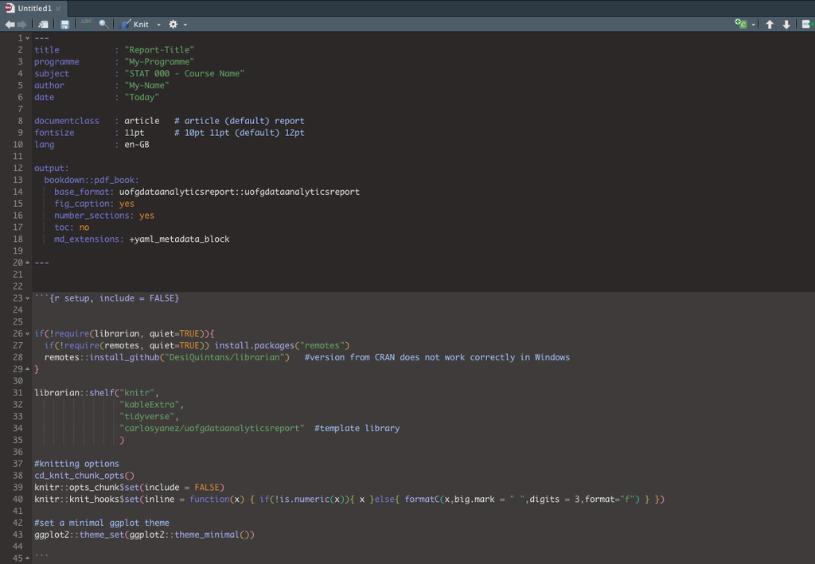

In addition, the *title_page* chunk contains functions that generate the below document properties - you can remove them or edit them (look at *?function* to see input options):

- **cd_header_footer()** generates the header and footer in each page.
- **cd_page_title()** creates the document’s front (title) page.
- **cd_toc()** creates the table of contents.

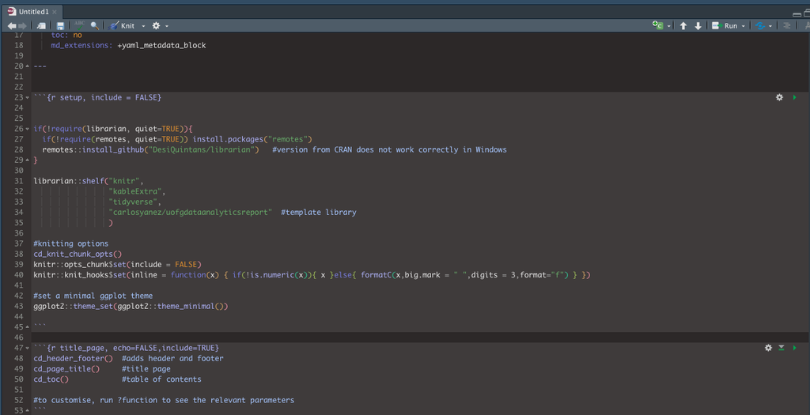

## Sample document

You can see a sample pdf [here](https://github.com/carlosyanez/uofgdataanalyticsreport/blob/main/example/Example.pdf).

## Credits and disclaimer

This template has been created using [{indiedown}](https://cynkra.github.io/indiedown/index.html).

Images and logos are property of the University of Glasgow. They are used here with the sole purpose of generating university reports or assignments.